# SRM Chapter 6.2

theBudgetActuary

# Hierarchical Clustering

Hierarchical clustering does not require a pre-specified number of groups like in k-means clustering. However, the goal remains the same which is to create groups of likewise observations. After completing the algorithm we are left with a dendrogram.

## Dendrogram

A dendrogram is a visual representation of the groupings of our data. Its shape resembles that of an upside down tree. Observations start from the bottom as individual leafs. They are then grouped together based off which observations are the most similar. (James et al.)

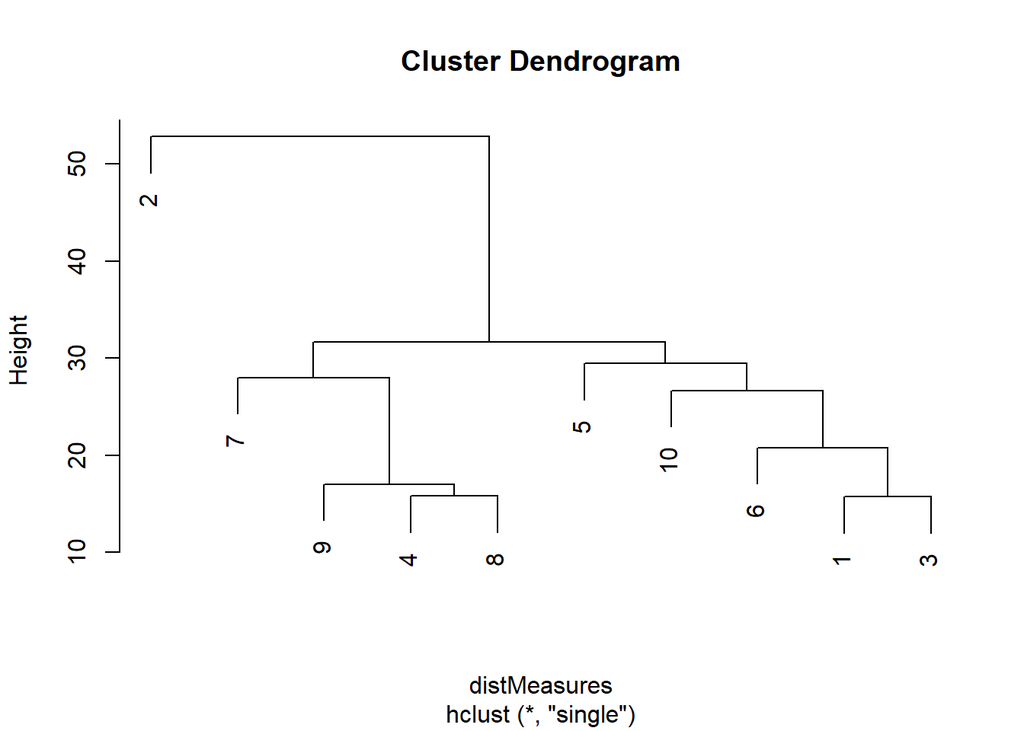

From the dendrogram above we can see the two most similar observations are 4 and 8, and 1 and 3. This is because they are fused at the lowest heights.

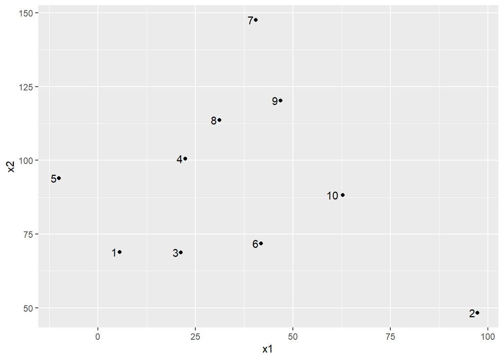

We can also see this in the scatter plot where observations 1 and 3, and observations 4 and 8 are nearest to each other.

The ultimate goal of hierarchical clustering is to split our data into clusters. After the dendrogram has been completed, the clusters can be created by creating a horizontal cut in our dendrogram. For instance, if the cut was made at the height of about 30 (y-axis value of 30), there would be three clusters:

cluster 1: observations (2)

cluster 2: observations (7,9,4,8)

cluster 3: observations (5,10,6,1,3)

The number of clusters we can create ranges from 1, meaning we used no cuts, to the number of observations, meaning we cut at height 0. The height at which we choose our cut can be arbitrary. Looking at our dendrogram above the number of groups I believe we should form would be two or three.

## Forming our Dendrogram

In order to start forming our dendrogram we must first decide which similarity measure we will use, which is generally either Euclidean Distance or correlation-based distance, and which linkage function to use, which is how we apply our similarity measurement between two groups of observations. (James et al.)

**Similarity Measures:**

Euclidean Distance: $\sqrt{\sum_{i=1}^{n} (q_{i}-p_{i})^{2}}$

correlation-based - Chooses similarity based off how correlated the features are.

**4 Linkage Choices:**

Complete - Uses the largest pairwise dissimilarity between the two groups.

Single - Uses the smallest pairwise dissimilarity between the two groups.

Average - Uses the average pairwise dissimilarity between the two groups.

Centroid - Uses the distance between the centroids of the two groups.

In order to identify which linkage function was used from a dendrogram, average and complete linkages tend to create more balanced dendrograms, while single linkage tends to create unbalanced dendrograms. Centroid linkage can lead to inversion, where a cluster is formed below the individual clusters in a dendrogram.

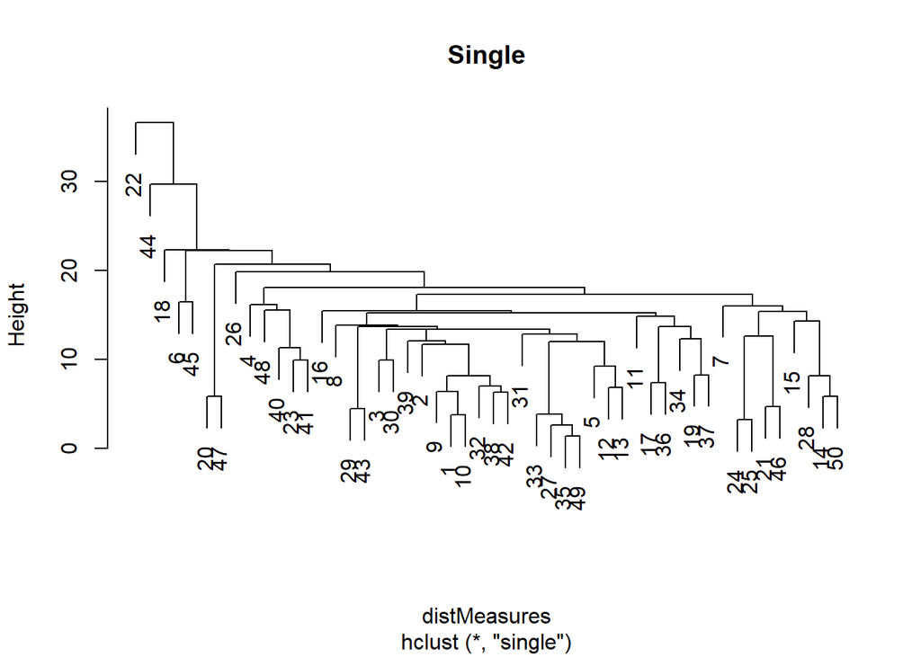

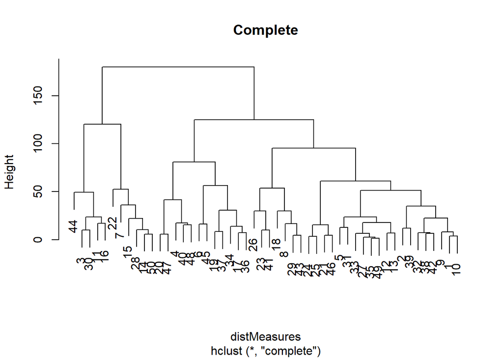

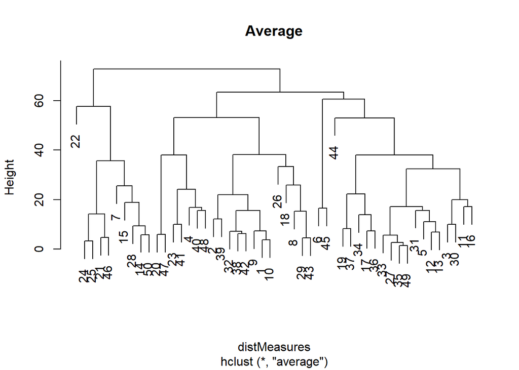

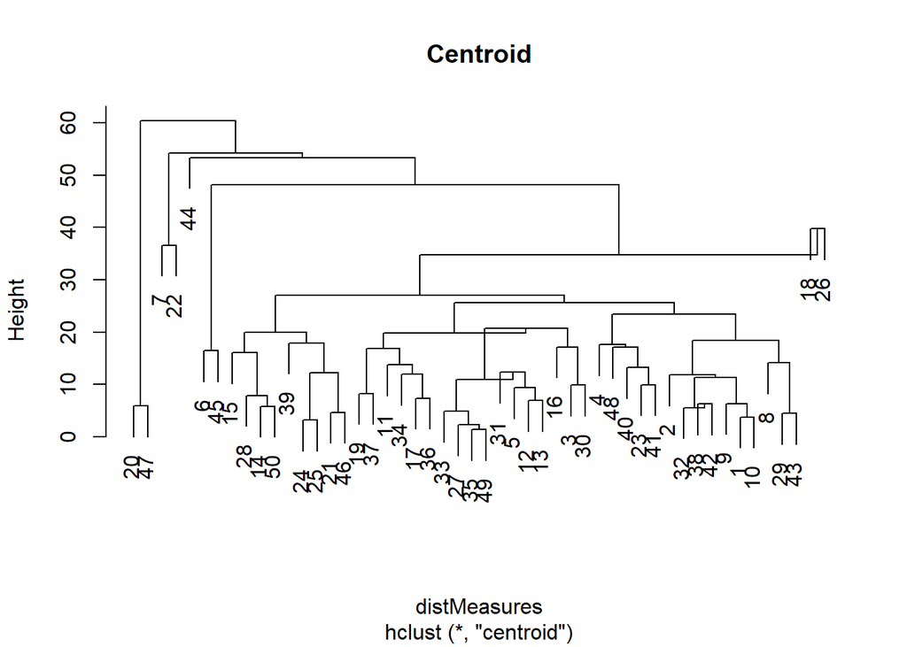

Once we have chosen our similarity measure and linkage function we can begin fusing our observation one by one. This means checking every possible combination of groupings and fusing at the one that creates the smallest value if euclidean distance is used, or largest value if the correlation-based measure is used, for whichever linkage function is chosen. This process continues until all observations are grouped together.

# Problems with Clustering Methods

For K-means clustering the k value must be chosen before even running our algorithm and the decision has to be made of whether or not to standardize the data. Whichever option we choose can drastically change our results.

For hierarchical clustering we must choose which similarity measure to use, which linkage function to use, where to group our data, and whether or not to standardize our data.

Generally, we can try several different approaches and choose the one that ultimately creates the most useful solution. (James et al.)

#### Sources:

James, G., Witten, D., Hastie, T., & Tibshirani, R. (n.d.). An introduction to statistical learning: With applications in R.